# The hyperparameter choice - pt. 1

In this notebook we will visualize the effect of the choice of elastic tree hyperparameters for the elastic and embedded tree. In this first part we will be working with the dataset by Guo *et al.*, detailing early embryogenesis in the mouse. We will be needing MERLoT as well as some customized versions of the MERLoT functions.

```r
library(merlot)
source("~/Documents/repos/merlot-scripts/scripts/niko_tree_funcs.R")
```

We will read the dataset and the annotation, as well as the diffusion map coordinates.

```r
# Read the example Guo dataset that is distributed with the package
DataFile= paste(find.package("merlot"), "/example/Guo2010.txt", sep="")
Dataset=ReadDataset(DataFile)
# Load the cell types
CellTypes=read.table(file=paste(find.package("merlot"), "/example/GuoFeatures.txt", sep=""), sep="\t", header = F, stringsAsFactors = F)
CellTypes=CellTypes[,2]
selected_colors=c("red", "orange", "yellow", "green", "cyan", "darkblue")
guo_colorcells=c()
guo_colorcells[which(CellTypes=="2C")]="red"
guo_colorcells[which(CellTypes=="4C")]="orange"
guo_colorcells[which(CellTypes=="8C")]="yellow"
guo_colorcells[which(CellTypes=="16C")]="green"
guo_colorcells[which(CellTypes=="32C")]="cyan"
guo_colorcells[which(CellTypes=="64C")]="darkblue"
CellCoordinates=read.table(file=paste(find.package("merlot"), "/example/GuoRotatedCoordinates.txt", sep=""),
                           sep="\t", header = F, stringsAsFactors = F)
CellCoordinates=as.matrix(CellCoordinates[,1:2])
```

We calculate the scaffold tree without local averaging. The Guo dataset only has 428 cells; reducing that further will only make MERLoT’s job harder.

```r
# We calculate the scaffold tree using the first 3 diffusion components from the diffusion map
ScaffoldTree=CalculateScaffoldTree(CellCoordinates = CellCoordinates, python_location = "~/miniconda3/envs/py36/bin/python")
```

```
Loaded Tree Topology Library...
Data Dimensions (428, 2)
Calculating distances...
Calculating Scaffold Tree...
Endpoints: 4 1 365 416 409
Branchpoints: 2 186 104
Tree_Branch 1 104
Tree_Branch 365 104
Tree_Branch 104 186
Tree_Branch 409 186
Tree_Branch 416 186
Finished Scaffold Tree... 3.598830223083496 seconds
```

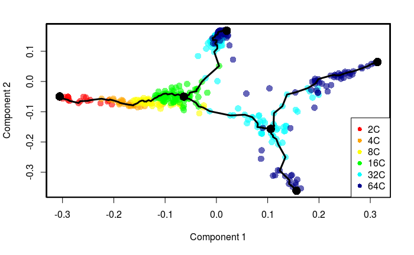

```r
plot_scaffold_tree(ScaffoldTree = ScaffoldTree, colorcells = guo_colorcells)
legend(x="bottomright", legend=c("2C", "4C", "8C", "16C", "32C", "64C"), col=selected_colors, pch=16)
```

We will now calculate the elastic tree with different elasticity hyperparameters: the MERLoT defaults and the values that ElPiGraph.R proposes for the `elastic_tree` algorithm.

```r
NumberOfNodes=100
ElasticTree <- CalculateElasticTree(ScaffoldTree = ScaffoldTree, N_yk = NumberOfNodes)
```

```
[1] "Constructing tree 1 of 1 / Subset 1 of 1"
[1] "Computing EPG with 100 nodes on 428 points and 2 dimensions"
[1] "Using a single core"
Nodes = 11 12 13 14 15 16 17 18 19 20 21 22 23 24 25 26 27 28 29 30 31 32 33 34 35 36 37 38 39 40 41 42 43 44 45 46 47 48 49 50 51 52 53 54 55 56 57 58 59 60 61 62 63 64 65 66 67 68 69 70 71 72 73 74 75 76 77 78 79 80 81 82 83 84 85 86 87 88 89 90 91 92 93 94 95 96 97 98 99
BARCODE ENERGY  NNODES  NEDGES  NRIBS   NSTARS  NRAYS   NRAYS2  MSE MSEP    FVE FVEP    UE  UR  URN URN2    URSD
2||100  0.0001627   100 99  94  2   0   0   0.0001337   0.0001253   0.9958  0.9961  1.254e-05   1.642e-05   0.001642    0.1642  0
25.798 sec elapsed
```

```r
nikoTree <- nikoElastic(ScaffoldTree = ScaffoldTree, N_yk = NumberOfNodes)
```

```
[1] "Constructing tree 1 of 1 / Subset 1 of 1"
[1] "Computing EPG with 100 nodes on 428 points and 2 dimensions"
[1] "Using a single core"
Nodes = 11 12 13 14 15 16 17 18 19 20 21 22 23 24 25 26 27 28 29 30 31 32 33 34 35 36 37 38 39 40 41 42 43 44 45 46 47 48 49 50 51 52 53 54 55 56 57 58 59 60 61 62 63 64 65 66 67 68 69 70 71 72 73 74 75 76 77 78 79 80 81 82 83 84 85 86 87 88 89 90 91 92 93 94 95 96 97 98 99
BARCODE ENERGY  NNODES  NEDGES  NRIBS   NSTARS  NRAYS   NRAYS2  MSE MSEP    FVE FVEP    UE  UR  URN URN2    URSD
2||100  0.000296    100 99  94  2   0   0   0.0001471   0.00014 0.9954  0.9956  0.0001378   1.108e-05   0.001108    0.1108  0
21.417 sec elapsed
```

```r
par(mfrow=c(1,2))
plot_elastic_tree(ElasticTree)
plot_elastic_tree(nikoTree)
```

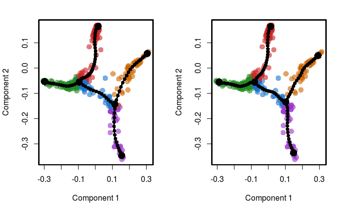

```r
par(mfrow=c(1,1))
```

The exact number of nodes per branch differs, and the exact positions of endpoints and branchpoints do not overlap, but we see that there are no big differences between using the MERLoT hyperparameters (left) and the ElPiGraph.R ones (right).

For the embedding in gene space, we will use (1) the MERLoT elastic tree with MERLoT hyperparameters (benchmarked in original benchmark), (2) the ElPi elastic tree with ElPi hyperparameters (benchmarked in extended benchmark), and (3) the ElPi elastic tree with MERLoT hyperparameters (not benchmarked).

```r
# Embedd the principal elastic tree on the gene expression space from which it was calculated.
EmbeddedTree= GenesSpaceEmbedding(ExpressionMatrix = Dataset$ExpressionMatrix, ElasticTree = ElasticTree)
```

```
[1] "Constructing tree 1 of 1 / Subset 1 of 1"
[1] "Computing EPG with 100 nodes on 428 points and 48 dimensions"
BARCODE ENERGY  NNODES  NEDGES  NRIBS   NSTARS  NRAYS   NRAYS2  MSE MSEP    FVE FVEP    UE  UR  URN URN2    URSD
[1] "Using a single core"
0.088 sec elapsed
```

```r
nikoEmb <- nikoEmbed(ExpressionMatrix = Dataset$ExpressionMatrix, ElasticTree = nikoTree)
```

```
[1] "Constructing tree 1 of 1 / Subset 1 of 1"
[1] "Computing EPG with 100 nodes on 428 points and 48 dimensions"
BARCODE ENERGY  NNODES  NEDGES  NRIBS   NSTARS  NRAYS   NRAYS2  MSE MSEP    FVE FVEP    UE  UR  URN URN2    URSD
[1] "Using a single core"
0.079 sec elapsed
```

```r
mixed = GenesSpaceEmbedding(ExpressionMatrix = Dataset$ExpressionMatrix, ElasticTree = nikoTree)
```

```
[1] "Constructing tree 1 of 1 / Subset 1 of 1"
[1] "Computing EPG with 100 nodes on 428 points and 48 dimensions"
BARCODE ENERGY  NNODES  NEDGES  NRIBS   NSTARS  NRAYS   NRAYS2  MSE MSEP    FVE FVEP    UE  UR  URN URN2    URSD
[1] "Using a single core"
0.091 sec elapsed
```

There is no immediate way to visualize the embedded tree, but we can plot the trees that result from the embedding in a schematic way, using the `plot_flattened_tree` function.

```r
par(mfrow=c(1,3))
plot_flattened_tree(EmbeddedTree, cell_annot = CellTypes, node_size = "cells")
plot_flattened_tree(nikoEmb, cell_annot = CellTypes, node_size = "cells")
```

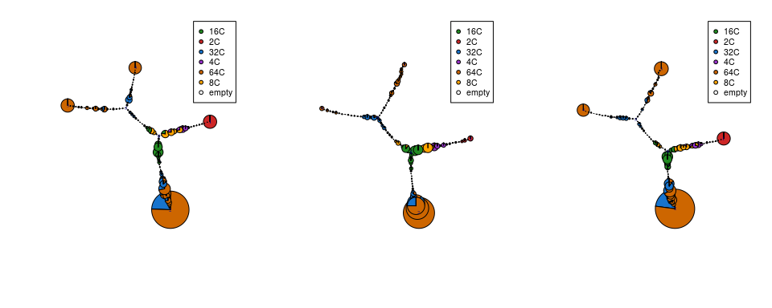

```r
plot_flattened_tree(mixed, cell_annot = CellTypes, node_size = "cells")
par(mfrow=c(1,1))
```

Again, there is no big difference except for the absence of cell clumps in the endpoints of three of the four branches. We will now calculate pseudotimes for each cell in every embedded tree:

```r
Pseudotimes=CalculatePseudotimes(EmbeddedTree, T0=1)
nikotimes = CalculatePseudotimes(nikoEmb, T0=1)
mixed_times = CalculatePseudotimes(mixed, T0=1)
```

With the pseudotimes available, we can now plot the expression of genes through pseudotime, allowing another comparison between the three approaches.

```r
par(mfrow=c(1, 3))
gene = "Gata4"
plot_pseudotime_expression_gene(GeneName = gene , EmbeddedTree = EmbeddedTree, Pseudotimes = Pseudotimes)
text(4, 10, labels = "A", cex = 3, adj=c(0.5, 0.5))
```

```r
plot_pseudotime_expression_gene(GeneName = gene , EmbeddedTree = nikoEmb, Pseudotimes = nikotimes)
text(4, 8.5, labels = "A", cex = 3, adj=c(0.5, 0.5))
```

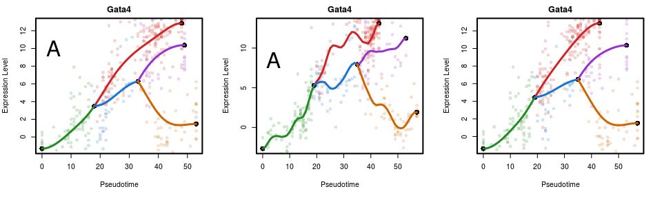

```r
plot_pseudotime_expression_gene(GeneName = gene , EmbeddedTree = mixed, Pseudotimes = mixed_times)
par(mfrow=c(1,1))
```

Here we see a big difference for the first time. The default ElPi parameters allow the expression of the pseudocells to overfit (middle). On the other hand, not using the MERLoT hyperparameters for the elastic tree doesn’t seem to affect the end result that much (left and right). We conclude that while the ElPi hyperparameters might produce good elastic trees (especially in conjuction with local averaging), they do not lend themselves to the creation of embedded trees, since they will overfit the data and produce less useful gene trajectories over time.

We include some more examples below. Always, from left to right: MERLoT+MERLoT, ElPi+ElPi, ElPi+MERLoT.

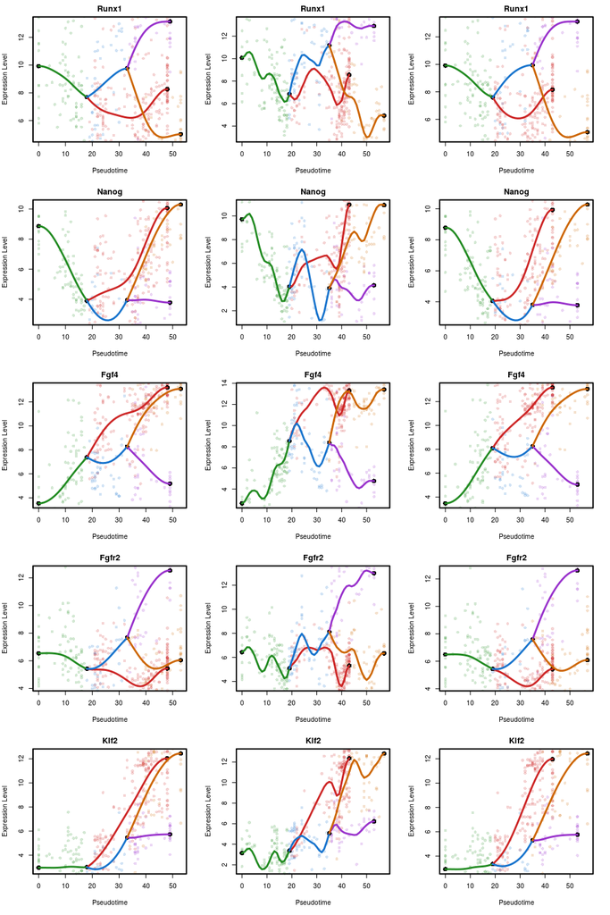